# Reproducible Research - Course Project 1

Luis Silva

June 1, 2019

### 1. Loading and preprocessing the data

1. Load the data

```r
if (!file.exists("activity.csv")) {
    unzip(zipfile="activity.zip")
}

activity = read.csv("activity.csv")
```

2. Process/transform the data (if necessary) into a format suitable for your analysis

```r
activity$date = as_date(activity$date)
```

### 2. What is mean total number of steps taken per day?

1. Calculate the total number of steps taken per day

```r
stepsByDate <- summarize(group_by(activity, date), steps=sum(steps,na.rm=TRUE))
stepsByDate
```

```
## # A tibble: 61 x 2
##    date       steps
##    <date>     <int>
##  1 2012-10-01     0
##  2 2012-10-02   126
##  3 2012-10-03 11352
##  4 2012-10-04 12116
##  5 2012-10-05 13294
##  6 2012-10-06 15420
##  7 2012-10-07 11015
##  8 2012-10-08     0
##  9 2012-10-09 12811
## 10 2012-10-10  9900
## # ... with 51 more rows
```

2. Make a histogram of the total number of steps taken each day

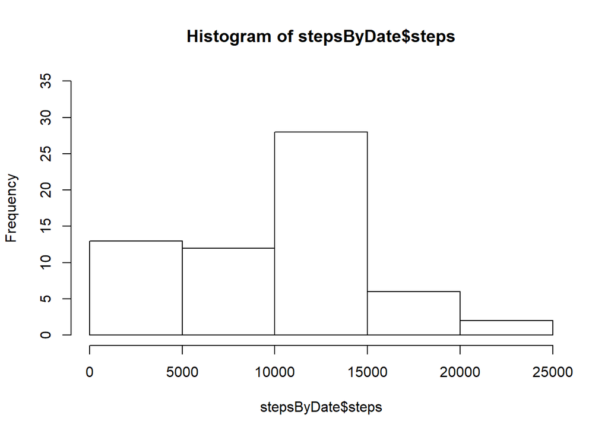

```r
hist(stepsByDate$steps, ylim=c(0,35))
```

```r
meanMedianByDate <- summarize(group_by(activity, date), mean=mean(steps,na.rm=TRUE), median=median(steps,na.rm=TRUE))
meanMedianByDate
```

```
## # A tibble: 61 x 3
##    date          mean median
##    <date>       <dbl>  <dbl>
##  1 2012-10-01 NaN         NA
##  2 2012-10-02   0.438      0
##  3 2012-10-03  39.4        0
##  4 2012-10-04  42.1        0
##  5 2012-10-05  46.2        0
##  6 2012-10-06  53.5        0
##  7 2012-10-07  38.2        0
##  8 2012-10-08 NaN         NA
##  9 2012-10-09  44.5        0
## 10 2012-10-10  34.4        0
## # ... with 51 more rows
```

### 3. What is the average daily activity pattern?

1. Make a time series plot of the 5-minute interval (x-axis) and the average number of steps taken, averaged across all days (y-axis)

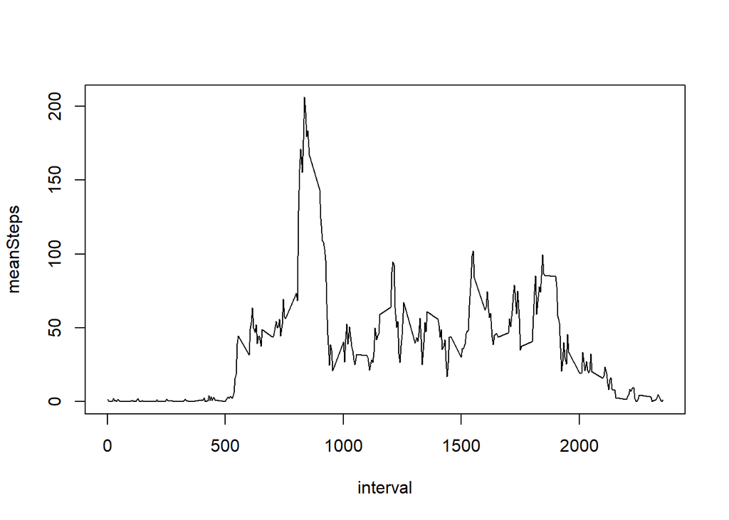

```r
meanStepsByInterval<-summarize(group_by(activity, interval), meanSteps=mean(steps,na.rm=TRUE))
with(meanStepsByInterval, plot(interval, meanSteps, type="l"))
```

2. Which 5-minute interval, on average across all the days in the dataset, contains the maximum number of steps?

```r
meanStepsByInterval$interval[which.max(meanStepsByInterval$meanSteps)]
```

```
## [1] 835
```

### 4. Imputing missing values

1. Calculate and report the total number of missing values in the dataset (i.e. the total number of rows with NAs)

```r
sum(is.na(activity$steps))
```

```
## [1] 2304
```

2. Devise a strategy for filling in all of the missing values in the dataset.
3. Create a new dataset that is equal to the original dataset but with the missing data filled in.

```r
activityToImpute = activity
activityToImpute = group_by(activityToImpute, interval)
activityComplete = mutate(activityToImpute,meanSteps=mean(steps,na.rm=TRUE),steps=replace(steps,which(is.na(steps)),first(meanSteps)))
activityComplete
```

```
## # A tibble: 17,568 x 4
## # Groups:   interval [288]
##     steps date       interval meanSteps
##     <dbl> <date>        <int>     <dbl>
##  1 1.72   2012-10-01        0    1.72
##  2 0.340  2012-10-01        5    0.340
##  3 0.132  2012-10-01       10    0.132
##  4 0.151  2012-10-01       15    0.151
##  5 0.0755 2012-10-01       20    0.0755
##  6 2.09   2012-10-01       25    2.09
##  7 0.528  2012-10-01       30    0.528
##  8 0.868  2012-10-01       35    0.868
##  9 0      2012-10-01       40    0
## 10 1.47   2012-10-01       45    1.47
## # ... with 17,558 more rows
```

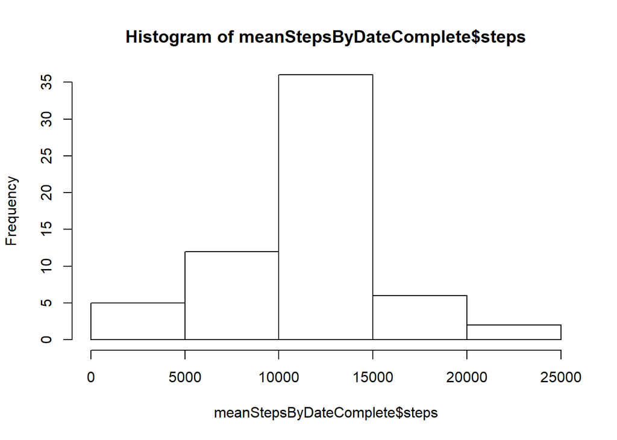

```r
meanStepsByDateComplete = summarize(group_by(activityComplete, date), steps=sum(steps), meanSteps=mean(steps), medianSteps=median(steps))
hist(meanStepsByDateComplete$steps, ylim=c(0,35))
```

```r
meanStepsByDateComplete
```

```
## # A tibble: 61 x 4
##    date        steps meanSteps medianSteps
##    <date>      <dbl>     <dbl>       <dbl>
##  1 2012-10-01 10766.    10766.      10766.
##  2 2012-10-02   126       126         126
##  3 2012-10-03 11352     11352       11352
##  4 2012-10-04 12116     12116       12116
##  5 2012-10-05 13294     13294       13294
##  6 2012-10-06 15420     15420       15420
##  7 2012-10-07 11015     11015       11015
##  8 2012-10-08 10766.    10766.      10766.
##  9 2012-10-09 12811     12811       12811
## 10 2012-10-10  9900      9900        9900
## # ... with 51 more rows
```

### 5. Are there differences in activity patterns between weekdays and weekends?

1. Create a new factor variable in the dataset with two levels - “weekday” and “weekend” indicating whether a given date is a weekday or weekend day.

```r
activityComplete = mutate(activityComplete, dateType = weekdays(date))
activityComplete$dateType[!activityComplete$dateType=="Saturday" & !activityComplete$dateType=="Sunday"] = "Weekday"
activityComplete$dateType[activityComplete$dateType=="Saturday" | activityComplete$dateType=="Sunday"] = "Weekend"
activityComplete
```

```
## # A tibble: 17,568 x 5
## # Groups:   interval [288]
##     steps date       interval meanSteps dateType
##     <dbl> <date>        <int>     <dbl> <chr>
##  1 1.72   2012-10-01        0    1.72   Weekday
##  2 0.340  2012-10-01        5    0.340  Weekday
##  3 0.132  2012-10-01       10    0.132  Weekday
##  4 0.151  2012-10-01       15    0.151  Weekday
##  5 0.0755 2012-10-01       20    0.0755 Weekday
##  6 2.09   2012-10-01       25    2.09   Weekday
##  7 0.528  2012-10-01       30    0.528  Weekday
##  8 0.868  2012-10-01       35    0.868  Weekday
##  9 0      2012-10-01       40    0      Weekday
## 10 1.47   2012-10-01       45    1.47   Weekday
## # ... with 17,558 more rows
```

2. Make a panel plot containing a time series plot (i.e. type = “l”) of the 5-minute interval (x-axis) and the average number of steps taken, averaged across all weekday days or weekend days (y-axis).

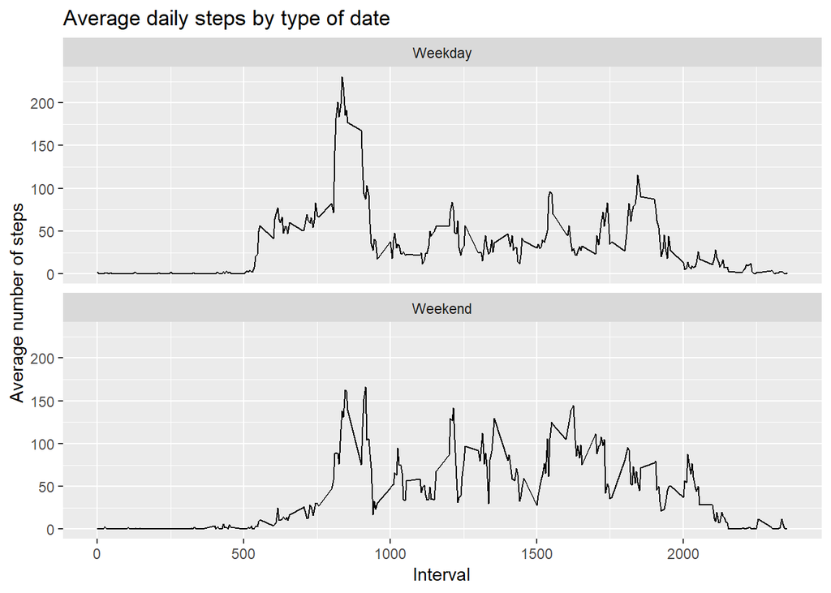

```r
activityCompleteByInterval = summarize(group_by(activityComplete, interval, dateType), meanSteps=mean(steps))
activityCompleteByInterval<-as.data.frame(activityCompleteByInterval)

activityCompleteByInterval$dateType<-as.factor(activityCompleteByInterval$dateType)

par(mfrow=c(2,1))
plot = ggplot(activityCompleteByInterval, aes(x = interval , y = meanSteps)) +
    geom_line() +
    labs(title = "Average daily steps by type of date", x = "Interval",
         y = "Average number of steps") +
    facet_wrap(~dateType, ncol = 1, nrow=2)
print(plot)
```